# team.Rmd

Felix Baez-Santiago and Brett White

9/14/2020

We will be exploring what aspects of the chocolates may affect taste. Before setting off to the exploration, answer the following questions.**

1. How are the ratings distributed? Create both a histogram and a boxplot and describe them. Don’t forget to mention outliers, if there are any.

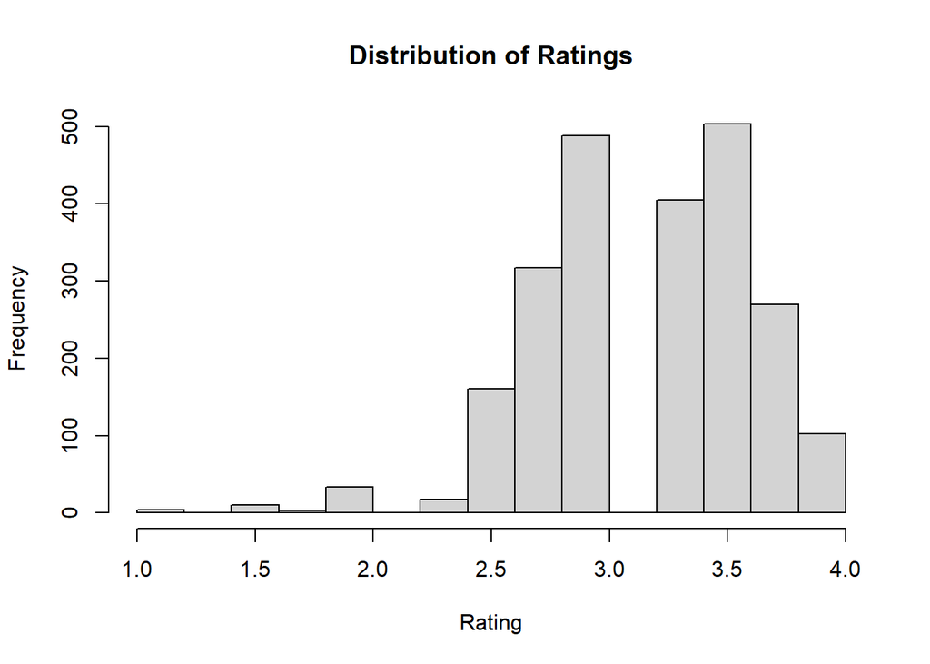

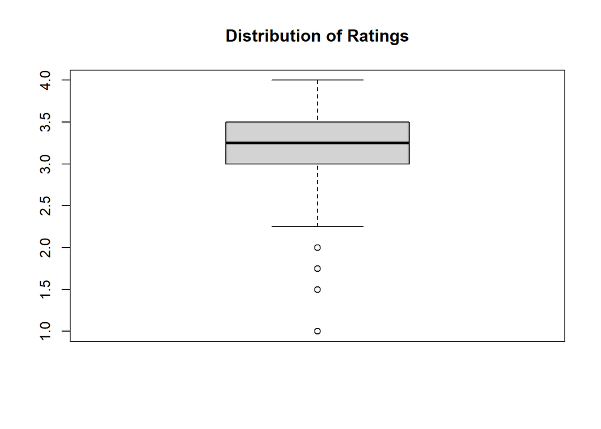

   The histogram for Ratings is bimodal with multiple outliers. The median rating is 3.25. Half of the ratings are between 3.0 and 3.5. The outliers are the poorly-rated chocolates (1.0-2.0).
2. How does the number of ratings depend on the year? Draw a bar chart of the number of reports.

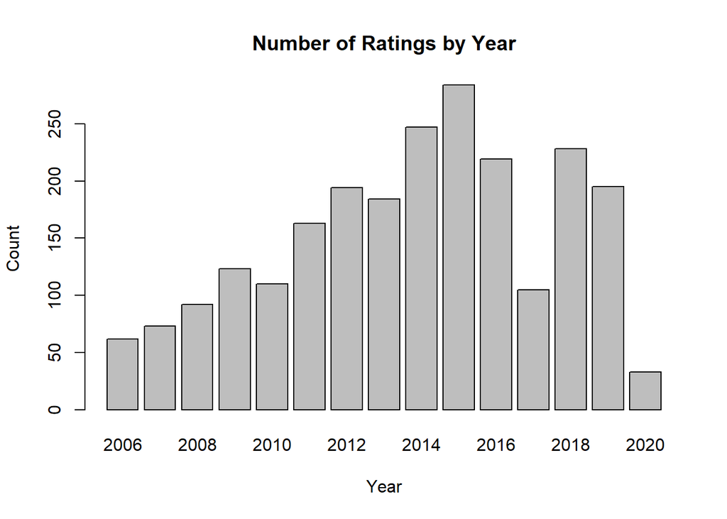

   The number of ratings increased each year from 2006 (when the earliest ratings were given) until 2015 with two exceptions (2010 and 2013). After 2015, the number of ratings decreased significantly in 2016 and even more in 2017 before increasing again to the number of ratings in 2016 in 2018. The number of ratings decreased a small amount in 2019, and there was a significant drop in 2020, though the ratings were last updated in March 2020 and so there may actually be more ratings now.
3. Do ratings depend on the cacao percentage of a chocolate bar? Create both numerical and graphical summaries, and explain.

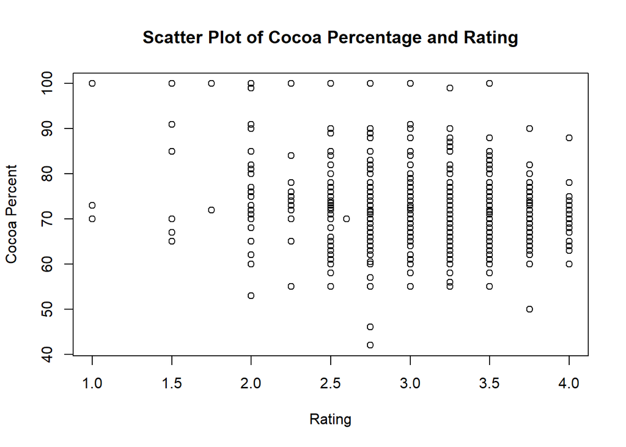

   The ratings don’t seem to depend on cocoa percentage. There are chocolates with ratings of 4.0 which vary in cocoa percentage from 60% to 88%. There are also ratings of 2.0 which vary in cocoa percentage from 53% to 100%. The cocoa percentage does not clearly increase or decrease as the rating increases. There is a lot of variability in cocoa percentage for each rating. The correlation coefficent is -0.1510178 which is very close to zero meaning that there is a very weak linear relationship between both variables.
4. How do different characteristics of the chocolate compare? To elaborate, which characteristics tend to be more favorable and which ones are not? Create both numerical and graphical summaries, and explain.

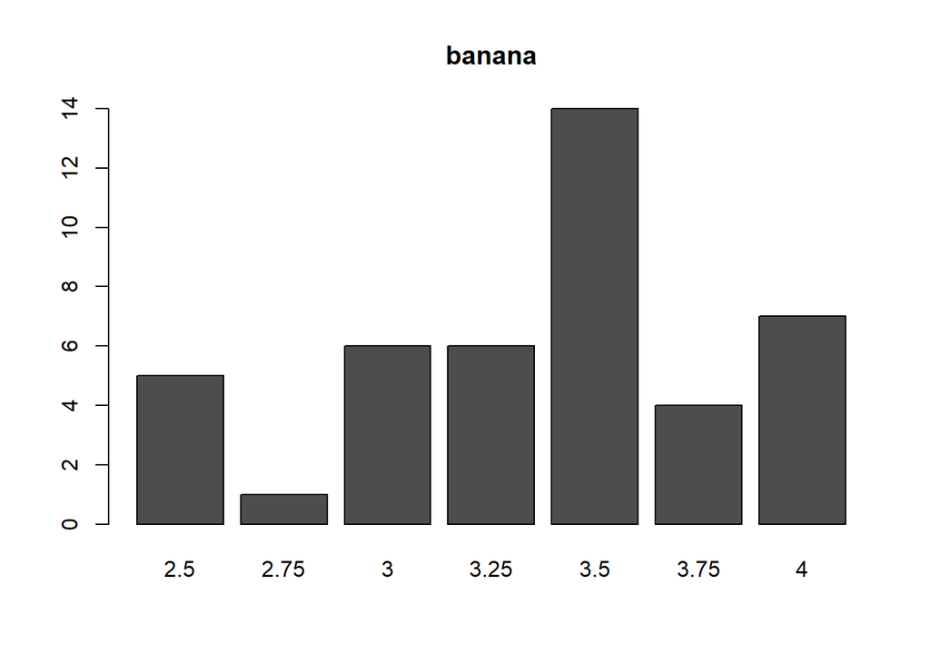

   ```
   ##    Min. 1st Qu.  Median    Mean 3rd Qu.    Max.
   ##   2.500   3.000   3.500   3.366   3.625   4.000
   ```

   The banana characteristic seems to be generally favorable with 43 chocolates having a mean rating of 3.37. 14 of those chocolates have a rating of 3.5.

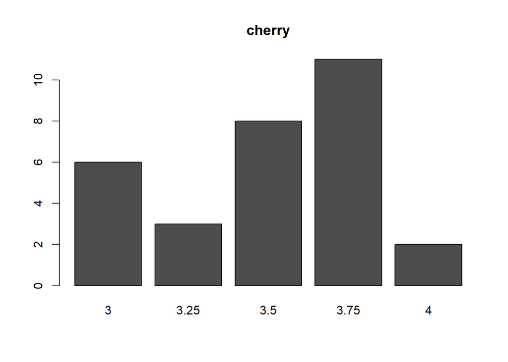

   ```
   ##    Min. 1st Qu.  Median    Mean 3rd Qu.    Max.
   ##    3.00    3.25    3.50    3.50    3.75    4.00
   ```

   The cherry characteristic seems to be generally favorable with 30 chocolates having a mean rating of 3.5. All 30 of those chocolates have a rating of at least 3.

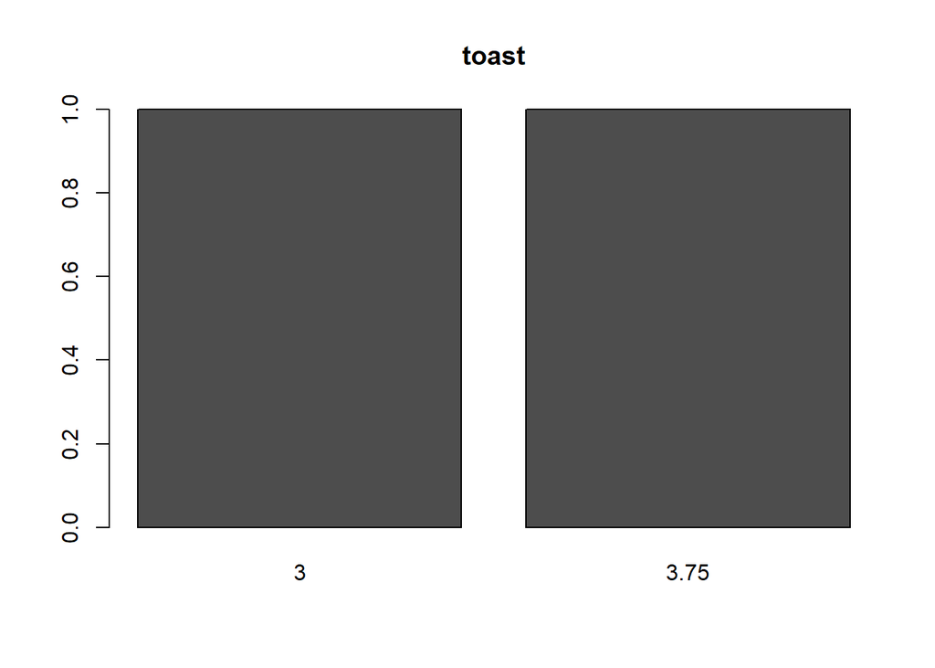

   ```
   ##    Min. 1st Qu.  Median    Mean 3rd Qu.    Max.
   ##   3.000   3.188   3.375   3.375   3.562   3.750
   ```

   The toast characteristic seems to be generally favorable with 2 chocolates having a mean rating of 3.38.

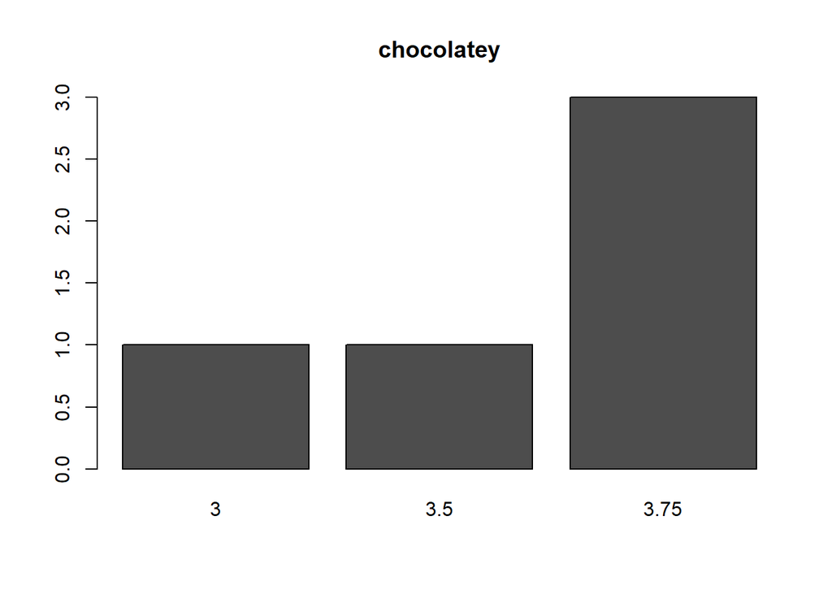

   ```
   ##    Min. 1st Qu.  Median    Mean 3rd Qu.    Max.
   ##    3.00    3.50    3.75    3.55    3.75    3.75
   ```

   The chocolately characteristic seems to be generally favorable with 5 chocolates having a mean rating of 3.55 with all ratings between 3 and 3.75, inclusive.

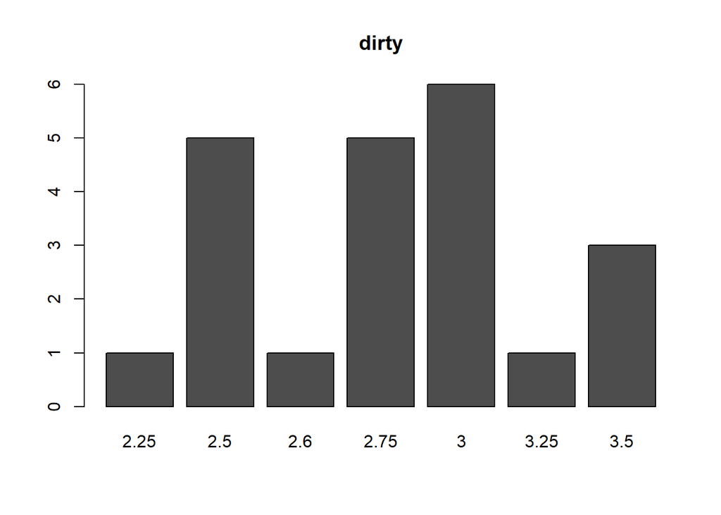

   ```
   ##    Min. 1st Qu.  Median    Mean 3rd Qu.    Max.
   ##   2.250   2.525   2.750   2.857   3.000   3.500
   ```

   The dirty characteristic has ratings ranging from 2.25 to 3.5 with a mean rating of 2.86. The 3.5 rating is surprising. Who would give dirty chocolate such a high rating?

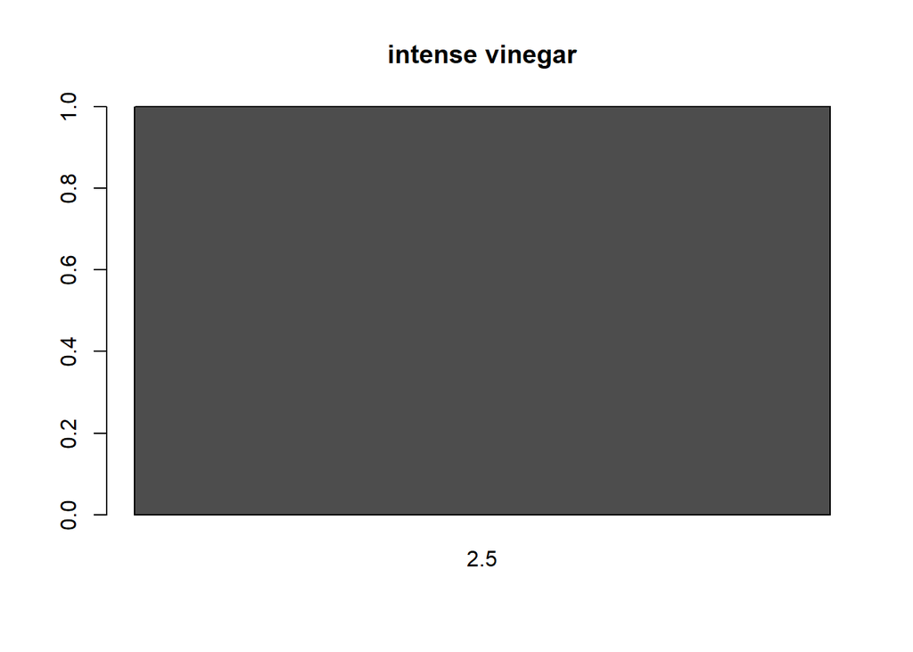

   ```
   ##    Min. 1st Qu.  Median    Mean 3rd Qu.    Max.
   ##     2.5     2.5     2.5     2.5     2.5     2.5
   ```

   The intense vinegar characteristic has 1 rating of 2.5 which is surprising because this is chocolate and one would think that chocolate with a characteristic of intense vinegar would be inedible.
5. Brainstorm two analyses you would like to perform with your teammate. Describe in plain language what comparisons are you making. Create suitable numerical and graphical summaries for your analyses. Describe the results.

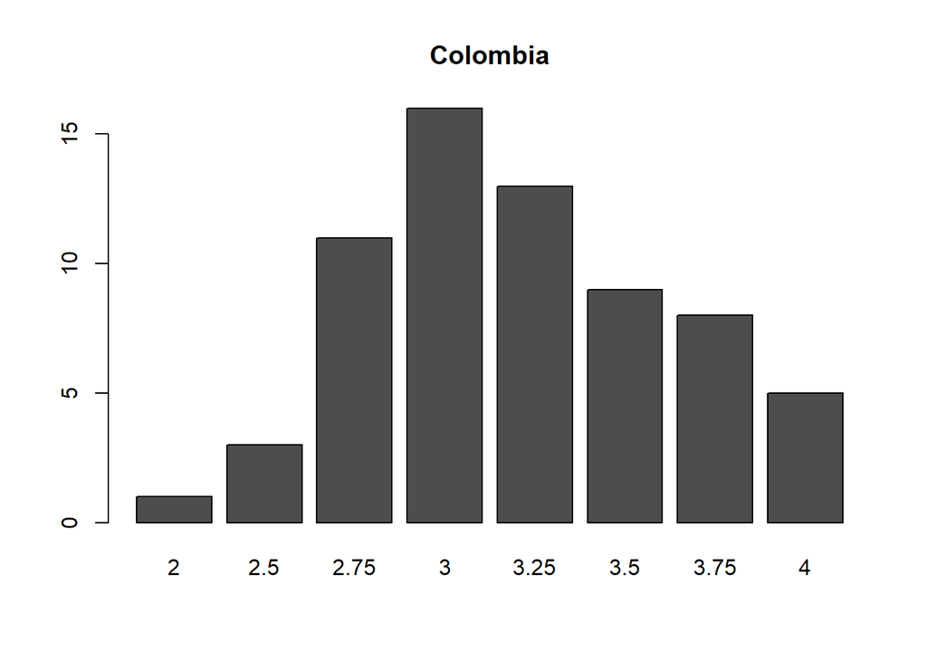

   ```
   ##    Min. 1st Qu.  Median    Mean 3rd Qu.    Max.
   ##   2.000   3.000   3.250   3.205   3.500   4.000
   ```

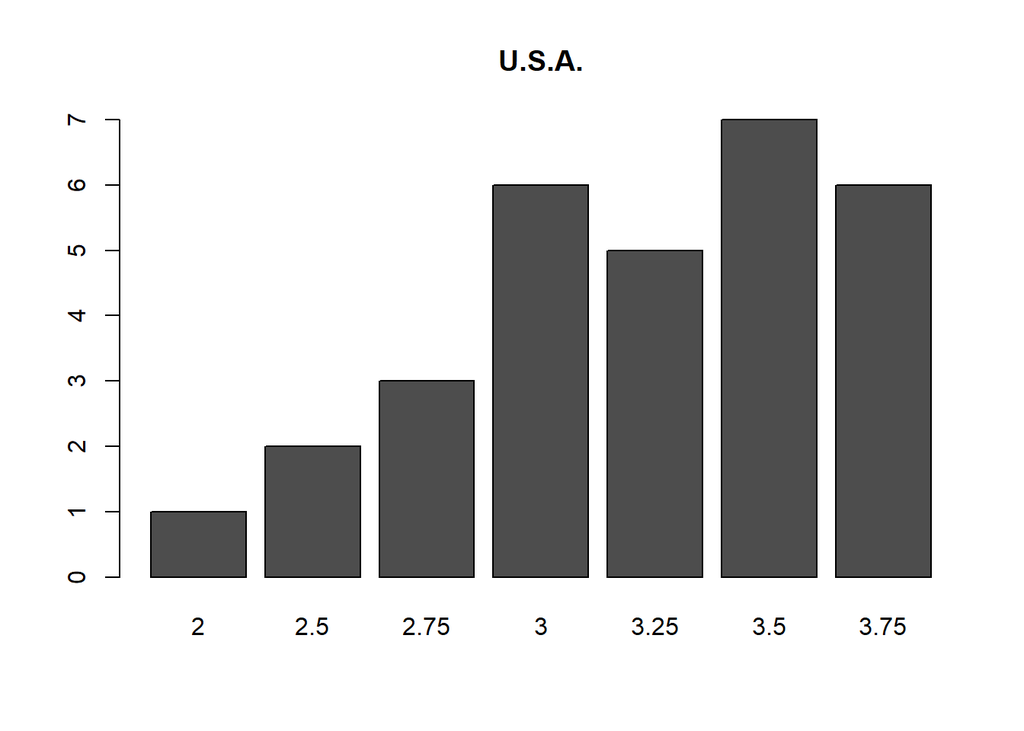

   ```
   ##    Min. 1st Qu.  Median    Mean 3rd Qu.    Max.
   ##   2.000   3.000   3.250   3.217   3.500   3.750
   ```

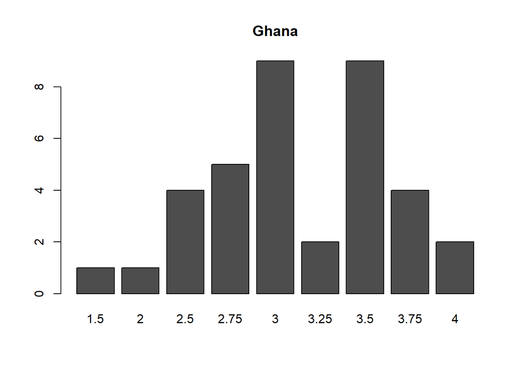

   ```
   ##    Min. 1st Qu.  Median    Mean 3rd Qu.    Max.
   ##   1.500   2.750   3.000   3.115   3.500   4.000
   ```

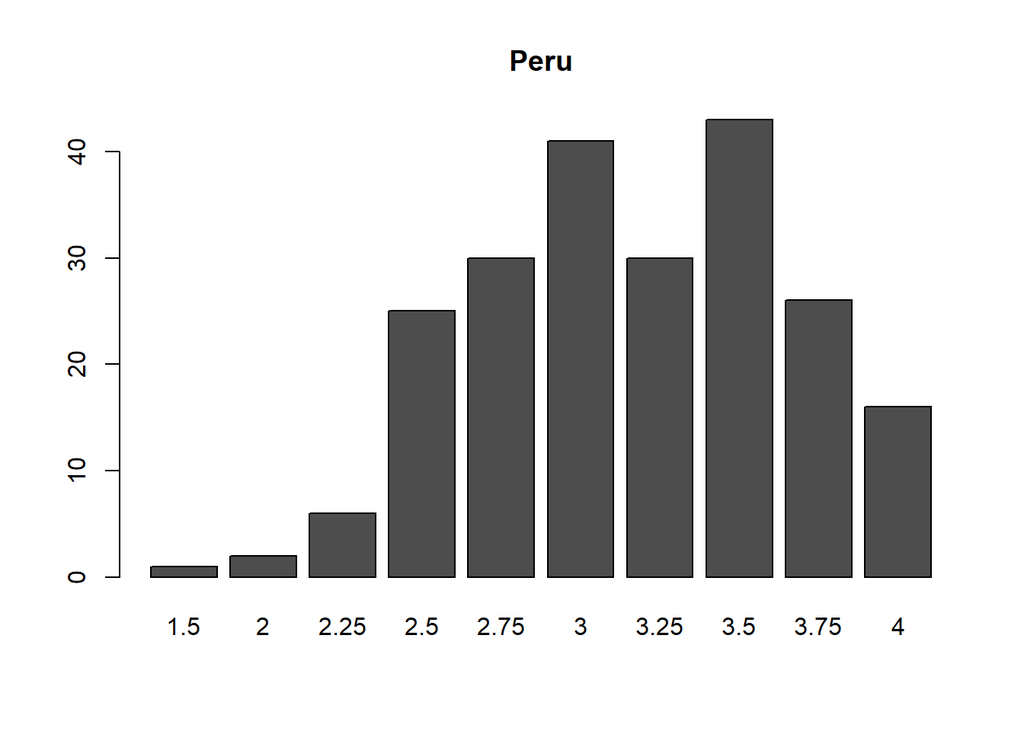

   ```
   ##    Min. 1st Qu.  Median    Mean 3rd Qu.    Max.
   ##   1.500   2.750   3.250   3.166   3.500   4.000
   ```

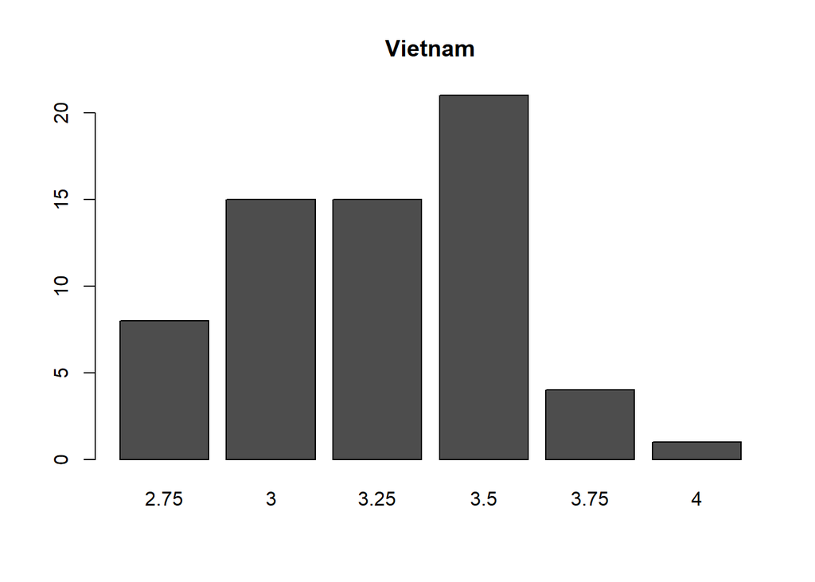

   ```
   ##    Min. 1st Qu.  Median    Mean 3rd Qu.    Max.
   ##   2.750   3.000   3.250   3.254   3.500   4.000
   ```

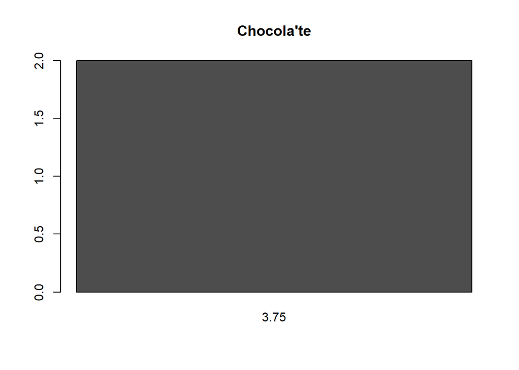

   ```
   ##    Min. 1st Qu.  Median    Mean 3rd Qu.    Max.
   ##    3.75    3.75    3.75    3.75    3.75    3.75
   ```

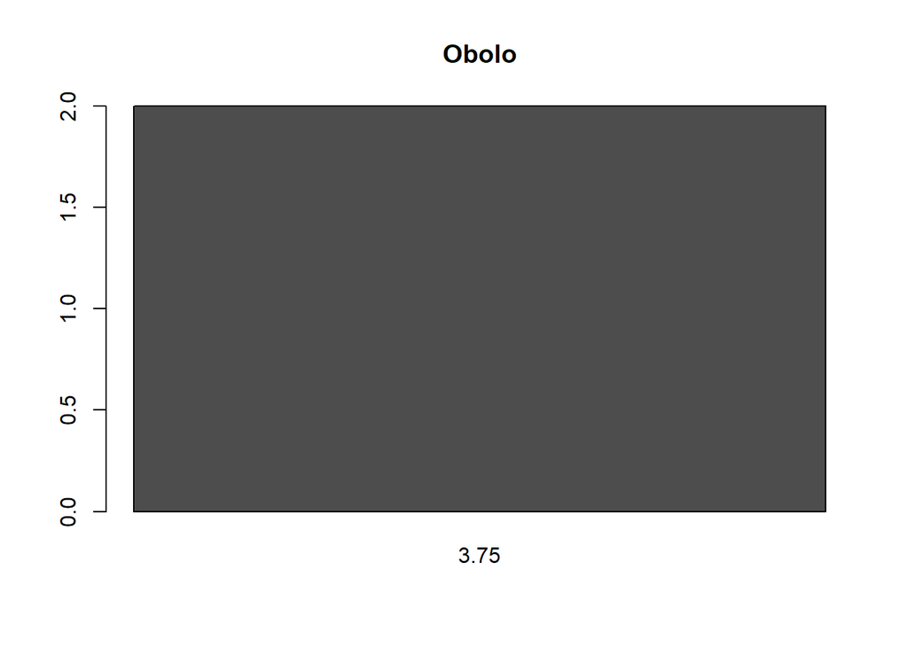

   ```
   ##    Min. 1st Qu.  Median    Mean 3rd Qu.    Max.
   ##    3.75    3.75    3.75    3.75    3.75    3.75
   ```

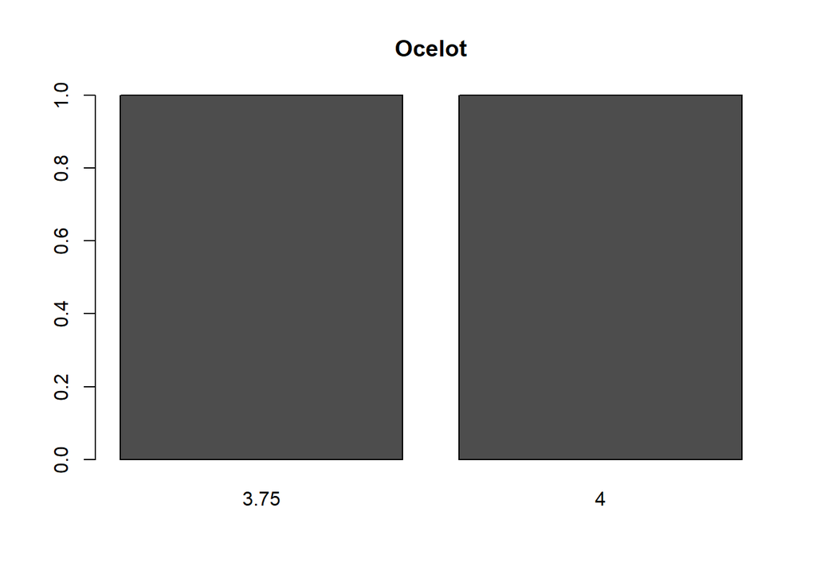

   ```
   ##    Min. 1st Qu.  Median    Mean 3rd Qu.    Max.
   ##   3.750   3.812   3.875   3.875   3.938   4.000
   ```

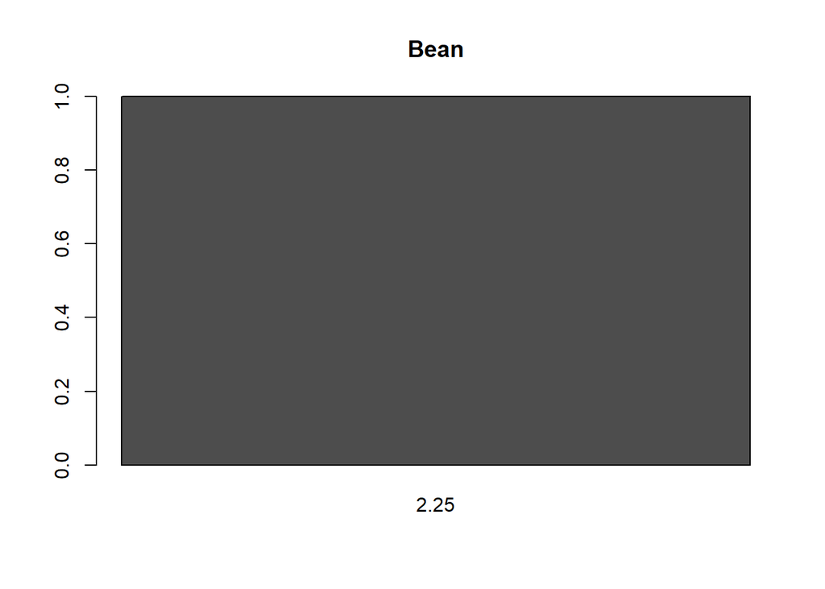

   ```
   ##    Min. 1st Qu.  Median    Mean 3rd Qu.    Max.
   ##    2.25    2.25    2.25    2.25    2.25    2.25
   ```

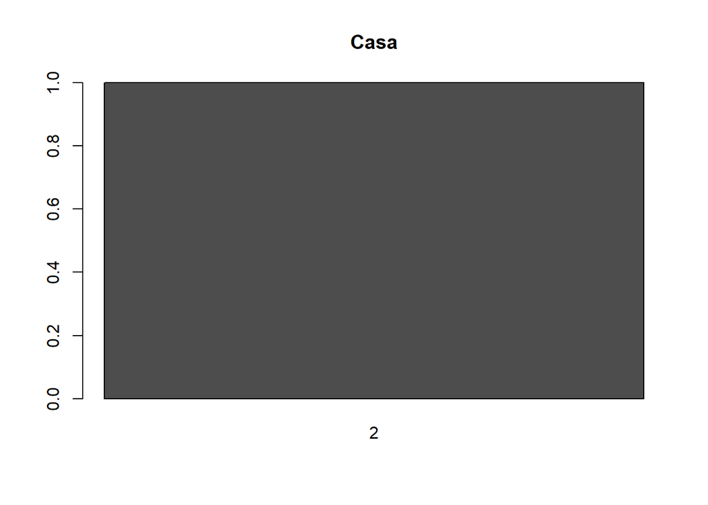

   ```
   ##    Min. 1st Qu.  Median    Mean 3rd Qu.    Max.
   ##       2       2       2       2       2       2
   ```

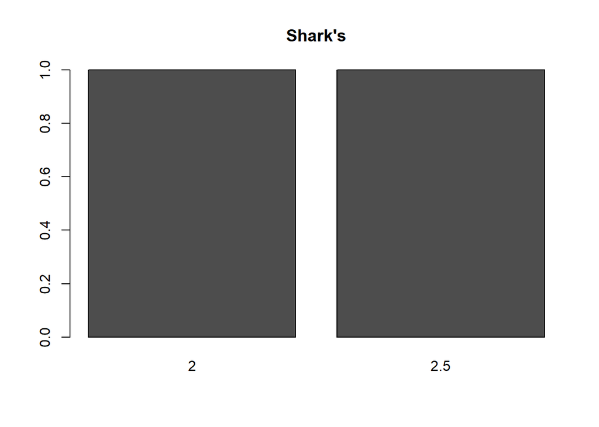

   ```
   ##    Min. 1st Qu.  Median    Mean 3rd Qu.    Max.
   ##   2.000   2.125   2.250   2.250   2.375   2.500
   ```

   We also compared chocolates from different companies based on mean rating. Chocola’te, Obolo, and Ocelot all had generally favorable chocolates with mean ratings of at least 3.75. Bean, Casa, and Shark’s all had generally unfavorable chocolates with mean ratings less than or equal to 2.5.